# Social preferences addendum

2017-November -9

## What constitutes a fair allocation?

- Equality-efficiency tradeoffs => spectrum of views on fairness
- Ignore issues of:
  - entitlement
  - desert
  - equity
- Theories of reciprocity parameterize fairness/kindness in terms of a material payoff (in the feasible distribution; think DG/UG)

## Konow (JEL, 2003) (not online)

Survey evidence that people reject these simplistic ideals in favor of:

- equity
- attribution
- proportionality
- desert

## Konow continued

- People should *be* held accountable for their choices, effort
- People should *not be* accountable for factors beyond their control
- Not clear exactly how *ability differences* fit in to prior theories of social preferences

## Cappelen et al (AER, 2007)

People are heterogeneous in their ideas of fairness

- Egalitarianism
- Libertarianism
- Intermediate ideals:
  - equity theory, accountability principle, etc.

## What’s fairness?

- "Fairness" means you are accountable for factors under your control
- Differences in income stemming from (some subset of)
  - effort,
  - individual choices,
  - innate ability, etc…
  - are "fair"
- But, inequality resulting from factors beyond agents’ control is not fair
- So, what factors are beyond agents’ control?

## Cappelen (2007)

Modified dictator games preceded by team production phase

- Agent \(i\) assigned return to investment, \(a_i\)
- Choose investment level, \(q_i\)
- Total income \(X(a, q) = a_iq_i + a_jq_j\) is divided between \(i\) and \(j\)
- Both \(i\) and \(j\) propose an allocation; one is chosen at random

## Why is this interesting?

Implied fair allocation to other subject:

- Egalitarianism \(\Rightarrow m_i(a, q) = X(a, q)/2\)
- Libertarianism \(\Rightarrow m_i(a, q) = a_i q_i\)
- "Liberal egalitarianism" \(\Rightarrow m_i(a, q) = \frac{q_i}{q_i +q_j} \cdot X(a, q)\)

## Details?

- Each participant was randomly assigned a low or a high rate of return.
  - Low \(\Rightarrow 2x\) investment
  - High \(\Rightarrow 4x\) investment
- Each participant got 300 NOK
- Could invest 0, 100, 200 NOK in one of two choices

## Four outcomes

1. both plays have same RoR & same investment
   - so fairness ideals then imply the same fair distribution (equal shares).
2. same RoR but differed in their investment level
   - liberal egalitarian = libertarian fairness
   - strict egalitarianism would differ.
3. same Investment, but different RoR
   - Only libertarians considered an unequal distribution fair in this class of situations.
4. different Investment & different RoR
   - if low RoR player invested more than high RoR, egalitarianism and libertarianism imply the same fair distribution.
   - Otherwise, the fairness ideals generally differ

## Summary Statistics

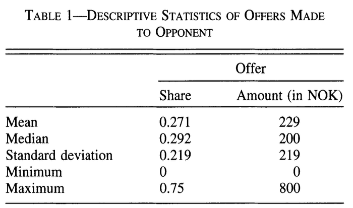

Table 1. from Cappelen et al (2007: 223).

## Model Estimates

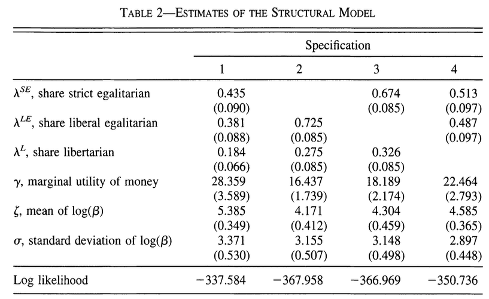

Table 2. from Cappelen et al (2007: 223).

## Conclusions?

- Really NB to think about heterogeneity
- Pretty complicated methods to detect & isolate
- Important policy implications (we get to later)
  - e.g. 1: crowding out
  - e.g. 2: assuming everyone self-interested?